# Power Comparison for Simulation Based on HDST

Jiaqiang Zhu

March 13th, 2020

Three Patterns Examined for Power Comparison

> Figure 0: Three Patterns (A): Layer E (B): Layer ONL (C): Layer GL

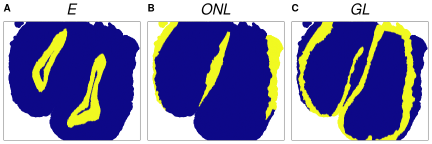

Pattern Plots

> Figure 1: 50X, numZero = 2000, sigZero = 200

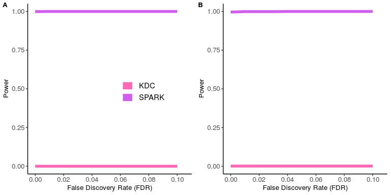

50X Power Comparison

> Figure 2: 25X, numZero = 2000, sigZero = 200

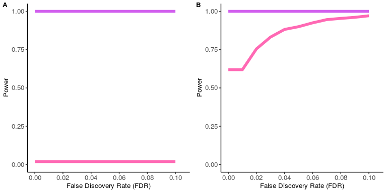

25X Power Comparison

> Figure 3: 20X, numZero = 2000, sigZero = 200

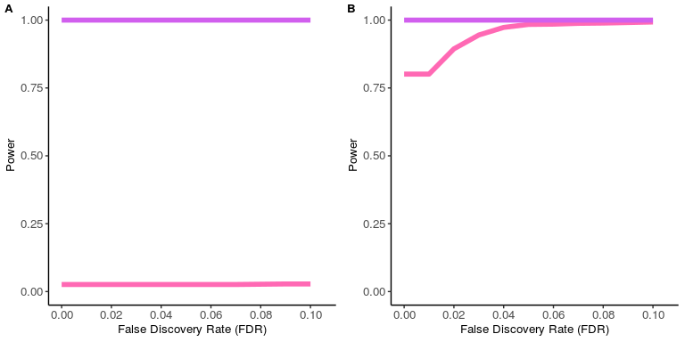

20X Power Comparison

> Figure 4: 15X, numZero = 2000, sigZero = 200

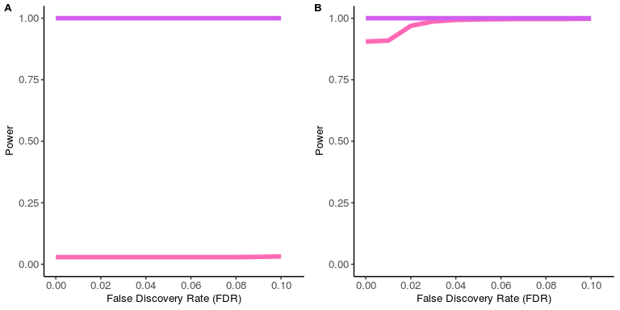

15X Power Comparison

> Figure 5: 10X, numZero = 2000, sigZero = 200

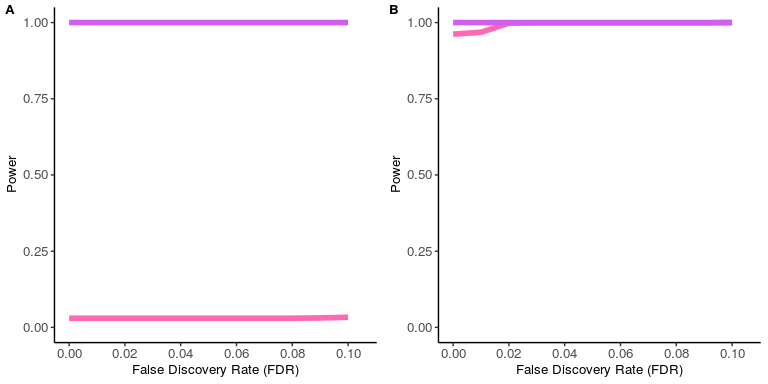

10X Power Comparison

> Figure 6: 50X, numZero = 1000, sigZero = 100

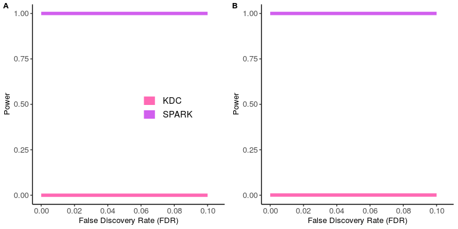

50X Power Comparison

> Figure 7: 25X, numZero = 1000, sigZero = 100

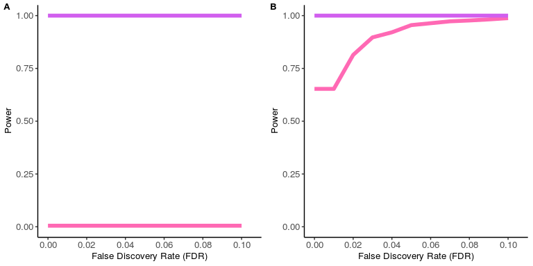

25X Power Comparison

> Figure 8: 20X, numZero = 1000, sigZero = 100

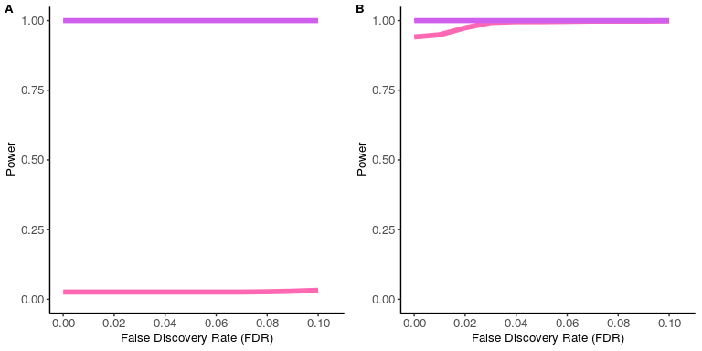

20X Power Comparison

> Figure 9: 15X, numZero = 1000, sigZero = 100

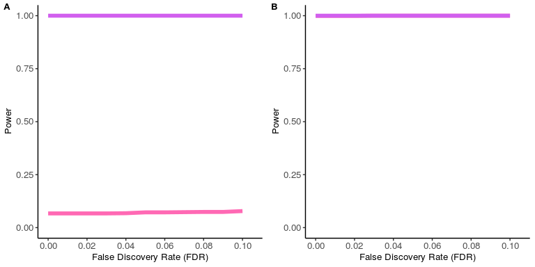

15X Power Comparison

> Figure 10: 10X, numZero = 1000, sigZero = 100

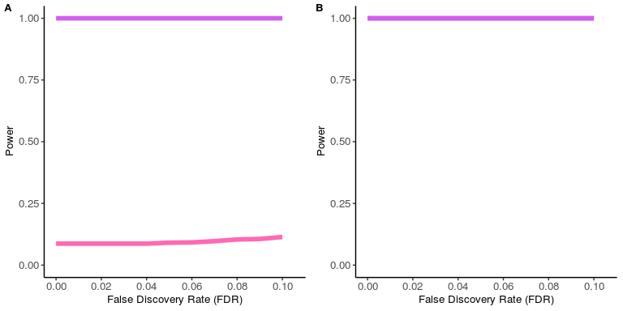

10X Power Comparison

> Figure 11: 50X, numZero = 5000, sigZero = 500

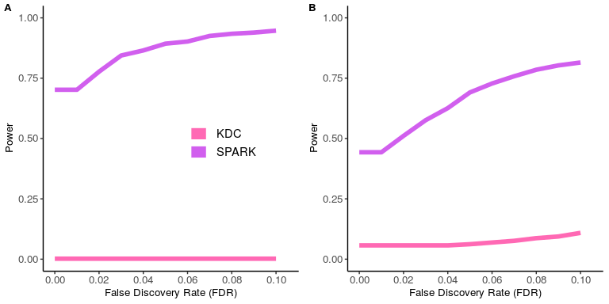

50X Power Comparison

> Figure 12: 25X, numZero = 5000, sigZero = 500

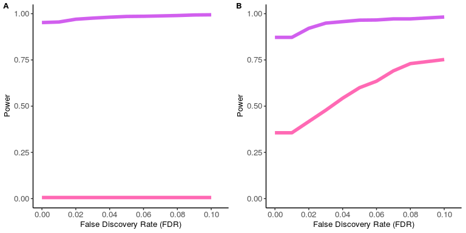

25X Power Comparison

> Figure 13: 20X, numZero = 5000, sigZero = 500

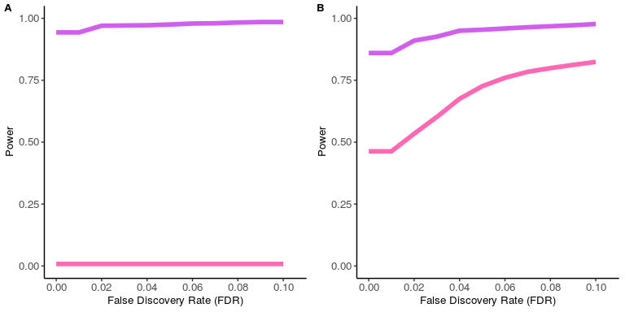

20X Power Comparison

> Figure 14: 15X, numZero = 5000, sigZero = 500

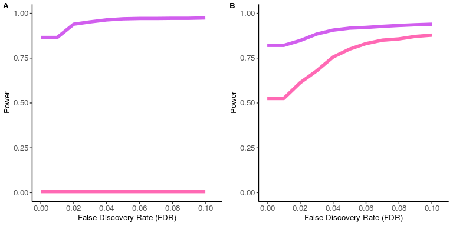

15X Power Comparison

> Figure 15: 10X, numZero = 5000, sigZero = 500

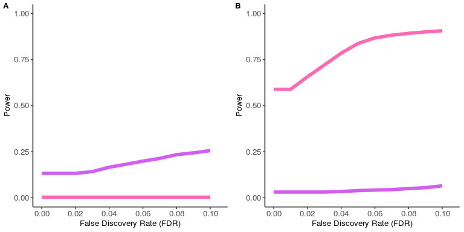

10X Power Comparison